# Deep analysis of trip length

## Data loading

I will load 2 pieces of data. The table exported from Bigquery containing information about day of trip, membership type, stations and number of trips. We will focus this analysis on the most frequented stations by casual members who are the target of the campaign.

```r
library(tidyverse)
#load data with readr
#some stations have no name. I will remove NA

bike_share_day<-read.csv("/Volumes/HP P500/Data Analyst capstone/bikeshare_analysis_20221107.csv",na="") %>% drop_na()

stations <- read.csv("/Volumes/HP P500/Data Analyst capstone/most_freq_stations_20221121.csv")


#a quick look
head(bike_share_day)
```

```
##             start_station_name num_trips_per_station day_of_trip
## 1 Monticello Ave & Chicago Ave                    15           7
## 2 Monticello Ave & Chicago Ave                     9           5
## 3 Monticello Ave & Chicago Ave                    11           6
## 4 Monticello Ave & Chicago Ave                    11           2
## 5 Monticello Ave & Chicago Ave                    10           1
## 6      Lamon Ave & Chicago Ave                    20           7
##   member_casual avg_ride_length
## 1        casual           18.60
## 2        casual            7.44
## 3        casual           21.18
## 4        casual           10.73
## 5        casual           27.90
## 6        casual           23.40
```

```r
head(stations)
```

```
##                   start_station_name num_trips_casual
## 1            Streeter Dr & Grand Ave            58383
## 2  DuSable Lake Shore Dr & Monroe St            32598
## 3                    Millennium Park            25990
## 4              Michigan Ave & Oak St            25327
## 5 DuSable Lake Shore Dr & North Blvd            23792
## 6                     Shedd Aquarium            20451
```

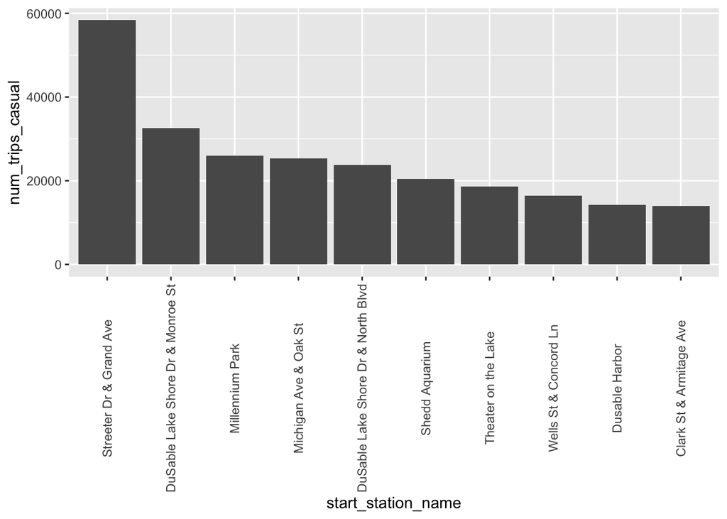

```r
#plot 10 top stations:

station_plot <- ggplot(data=stations) +
  geom_col(aes(x=start_station_name,y=num_trips_casual)) +
  theme(axis.text.x = element_text(angle=90,vjust=0.5)) +
  scale_x_discrete(limits = stations$start_station_name)

show(station_plot)
```

## Data Analysis and report

Now that we have our data loaded we can dig into it. I will analyze in which day there are more casual members for each station so marketing can focus the campaign on those days. To have a panoramic for the 10 stations I will plot them on a grid of graphics.

[figure not shown]

```r
#First I filter only the 10 most popular stations for casual bikers.
library(ggplot2)

bike_share_top <- bike_share_day %>% filter(start_station_name %in% stations$start_station_name) %>% mutate(day_of_trip=factor(day_of_trip))





plot <- ggplot(data=bike_share_top) + geom_point(mapping=aes(x=day_of_trip,y=num_trips_per_station,color=member_casual,size=avg_ride_length,alpha=0.8)) +
  facet_wrap(~start_station_name)+
  labs(title = "bike trips per weekday", x = "day of the week", y="number of trips")+
  scale_x_discrete(limits=c(2, 3, 4, 5, 6,7,1), labels=c( "Tue", "Wed", "Thu", "Fri", "Sat","Sun","Mon"))+
  guides(alpha=FALSE) +
  theme(axis.text.x = element_text(angle=90,vjust=0.5),
        strip.text.x = element_text(size = 5))
show(plot)
```

Also we can note that casual trips are longer. This could be due to that leisure trips are usually longer or that purchasing a single day or single trip pass for a short trip is not attractive.